# student_analysis

```
## [1] 281  27
```

```
## 'data.frame':    281 obs. of  27 variables:
##  $ X                       : int  0 1 2 3 4 5 6 7 8 9 ...
##  $ COLLEGE.ROLL.NUMBER     : int  201501001 201501002 201501003 201501004 201501005 201501006 201501007 201501008 201501009 201501010 ...
##  $ NAME                    : Factor w/ 279 levels "ABDUL AZEEZ K",..: 1 2 3 4 5 6 7 8 9 10 ...
##  $ GENDER                  : Factor w/ 2 levels "F","M": 2 1 2 1 1 1 2 1 1 2 ...
##  $ DOB                     : int  1997 1997 1997 1998 1997 1997 1997 1997 1997 1997 ...
##  $ SSLC.Marks              : num  95 100 96 94.2 84 96 92 93.6 98 96.6 ...
##  $ HSC.Marks               : num  89.1 92.2 94.8 94.6 77.1 ...
##  $ AGE                     : num  NA NA NA NA NA NA NA NA 20 NA ...
##  $ SSLC.DISTRICT           : Factor w/ 31 levels "","ap","ariyalur",..: 29 5 1 21 1 29 1 5 5 1 ...
##  $ SSLC.BOARD              : Factor w/ 4 levels "","cbse","icse",..: 4 2 1 4 1 2 1 4 4 1 ...
##  $ HSC.DISTRICT            : Factor w/ 31 levels "","ap","ariyalur",..: 29 5 1 20 1 29 1 5 5 1 ...
##  $ NATIVE.PLACE            : Factor w/ 61 levels "","alangulam ",..: 6 9 1 9 1 55 1 9 9 1 ...
##  $ NATIVE.DISTRICT         : Factor w/ 47 levels "","avadi","calicut ",..: 44 4 1 4 1 44 1 4 4 1 ...
##  $ LANGUAGES.KNOWN         : Factor w/ 20 levels "","can read and write korean",..: 4 2 1 4 1 4 1 4 4 1 ...
##  $ PASSPORT                : Factor w/ 3 levels "","no","yes": 2 3 1 3 1 3 1 2 3 1 ...
##  $ CERTIFICATION.COURSES   : Factor w/ 52 levels ""," 1. HONOURS DIPLOMA IN COMPUTER APPLICATION 2. ZOHO CREATOR CERTIFIED ASSOCIATE(ZCCA) 3. COLLEGE TO CORPORATE(T"| __truncated__,..: 2 3 1 1 1 52 1 1 1 1 ...
##  $ COURSE.DURATION..MONTHS.: Factor w/ 40 levels "","0","1","1 month",..: 13 2 1 1 1 17 1 1 1 1 ...
##  $ INSTITUTION.NAME        : Factor w/ 45 levels "","0","1. APOLLO COMPUTER EDUCATION LTD., 2. ITK EDUCATION SERVICES & ZOHO CORP., 3. IIT BOMBAY 4. INTERNSHALA  5. NPT"| __truncated__,..: 3 1 1 1 1 43 1 1 1 1 ...
##  $ PROFESSIONAL.EXPERIENCE : Factor w/ 7 levels "","                 NA",..: 7 5 1 1 1 1 1 1 1 1 ...
##  $ NAME.OF.COMPANY         : Factor w/ 17 levels "","0","HASURA",..: 3 1 1 1 1 1 1 1 1 1 ...
##  $ DESIGNATION             : Factor w/ 16 levels ""," INTERN UNDER RUBY ON RAILS",..: 14 1 1 1 1 1 1 1 1 1 ...
##  $ DURATION                : Factor w/ 13 levels "","0","1","1 month",..: 10 1 1 1 1 1 1 1 1 1 ...
##  $ Branch                  : Factor w/ 5 levels "CSE-A","CSE-B",..: 1 1 1 1 1 1 1 1 1 1 ...
##  $ Fail                    : int  0 0 3 2 4 0 0 3 0 0 ...
##  $ CGPA                    : num  7.33 7.62 6.48 6.53 6.18 6.88 6.77 6.36 7.98 7.86 ...
##  $ Num.of.languages        : int  1 1 0 1 0 1 0 1 1 0 ...
##  $ Num.of.courses          : int  1 1 0 0 0 2 0 0 0 0 ...
```

```
##        X       COLLEGE.ROLL.NUMBER                     NAME     GENDER
##  Min.   :  0   Min.   :201501001   PARTHIBAN R           :  2   F:122
##  1st Qu.: 70   1st Qu.:201501078   PRASANNA VENKATESH P S:  2   M:159
##  Median :140   Median :201501150   ABDUL AZEEZ K         :  1
##  Mean   :140   Mean   :201501149   ABENAYAA S SUNDARAM   :  1
##  3rd Qu.:210   3rd Qu.:201501220   ABHISHEK S            :  1
##  Max.   :280   Max.   :201501300   ABINAYA M             :  1
##                                    (Other)               :273
##       DOB         SSLC.Marks      HSC.Marks          AGE
##  Min.   :1996   Min.   : 58.0   Min.   :54.67   Min.   :18.00
##  1st Qu.:1997   1st Qu.: 88.0   1st Qu.:81.20   1st Qu.:19.00
##  Median :1997   Median : 93.4   Median :89.08   Median :20.00
##  Mean   :1997   Mean   : 91.0   Mean   :85.87   Mean   :19.73
##  3rd Qu.:1998   3rd Qu.: 96.0   3rd Qu.:92.58   3rd Qu.:20.00
##  Max.   :1998   Max.   :106.6   Max.   :96.92   Max.   :21.00
##  NA's   :1                                      NA's   :202
##       SSLC.DISTRICT       SSLC.BOARD        HSC.DISTRICT
##              :128              :127               :127
##  chennai     : 79   cbse       : 46   chennai     : 80
##  kanchipuram : 17   icse       :  1   kanchipuram : 17
##  thiruvallur :  8   state board:107   thiruvallur : 10
##  kancheepuram:  7                     kancheepuram:  6
##  vellore     :  7                     vellore     :  6
##  (Other)     : 35                     (Other)     : 35
##         NATIVE.PLACE    NATIVE.DISTRICT           LANGUAGES.KNOWN
##               :128              :130                      :130
##  chennai      : 81   chennai    : 77    english           :116
##  kanchipuram  :  4   kanchipuram: 12    english           :  9
##  tirunelveli  :  3   vellore    :  7    english,french    :  7
##  ambur        :  2   cuddalore  :  4    english and french:  2
##  andra pradesh:  2   tirunelveli:  3    english, french   :  2
##  (Other)      : 61   (Other)    : 48    (Other)           : 15
##  PASSPORT          CERTIFICATION.COURSES COURSE.DURATION..MONTHS.
##     :143                      :214              :214
##  no : 80   BIG DATA           :  5       1 WEEK :  9
##  yes: 58   PROGRAMMING IN JAVA:  5       1 MONTH:  8
##            ETHICAL HACKING    :  3       0      :  4
##            ZCCA               :  3       10 DAYS:  3
##            0                  :  2       2      :  3
##            (Other)            : 49       (Other): 40
```

[output cut: 25 more lines]

```
##                             :262          :259   CSE-A:55
##  NIL                        :  3   0      :  5   CSE-B:58
##  0                          :  2   1      :  3   CSE-C:60
##  INTERN                     :  2   3      :  3   CSE-D:53
##   INTERN UNDER RUBY ON RAILS:  1   NIL    :  3   CSE-E:55
##  IMPLANT TRAINING           :  1   1 month:  1
##  (Other)                    : 10   (Other):  7
##       Fail             CGPA       Num.of.languages Num.of.courses
##  Min.   : 0.000   Min.   :5.560   Min.   :0.0000   Min.   :0.000
##  1st Qu.: 0.000   1st Qu.:6.430   1st Qu.:0.0000   1st Qu.:0.000
##  Median : 1.000   Median :7.050   Median :1.0000   Median :0.000
##  Mean   : 2.164   Mean   :7.106   Mean   :0.6192   Mean   :0.395
##  3rd Qu.: 3.000   3rd Qu.:7.820   3rd Qu.:1.0000   3rd Qu.:0.000
##  Max.   :13.000   Max.   :8.710   Max.   :3.0000   Max.   :7.000
##
```

The dataset concists of 281 rows and 27 columns.The dataset contain the details of students inluding their marks, course details and others. The accuracy of analysis may not be so accurate because there are lot of missing values in the categorical variables. Analysis is done based on the available details to uncover some insights.

# univariate analysis

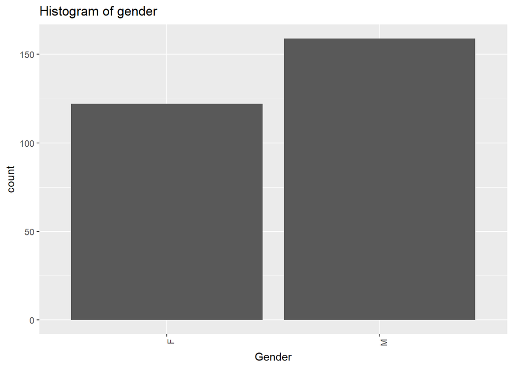

In the Computer Science department based on the available details, the number of boys are more in numbers that does girls.

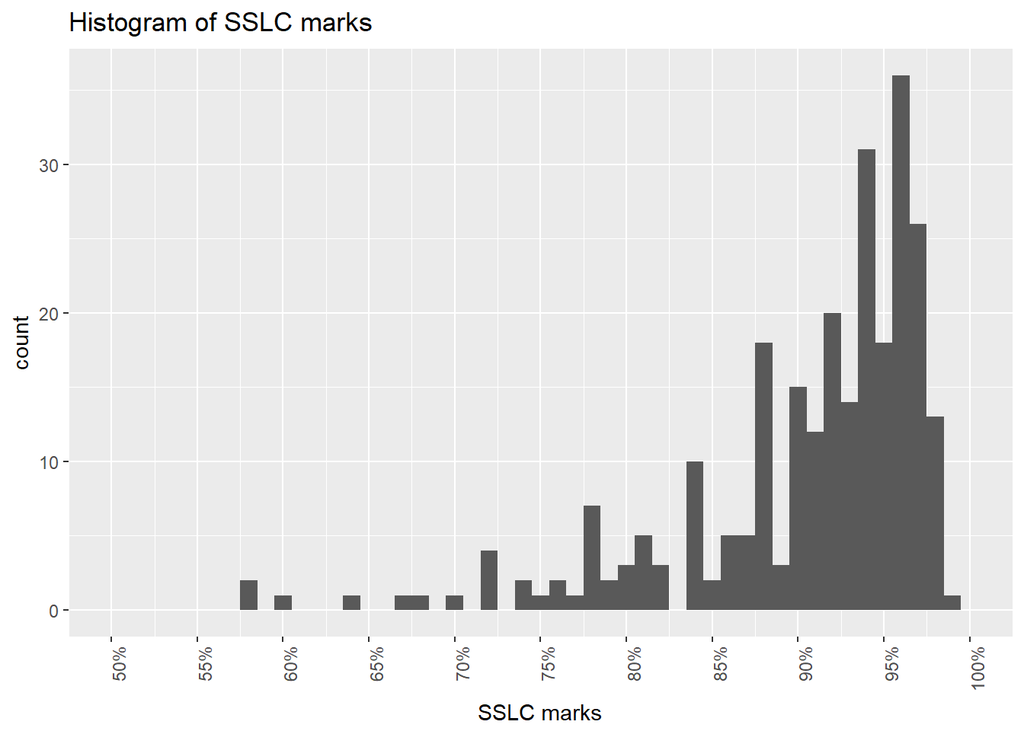

The above histogram represents the distribution of 10th marks.It is clear that most of the students have secured marks between 83% and 98%

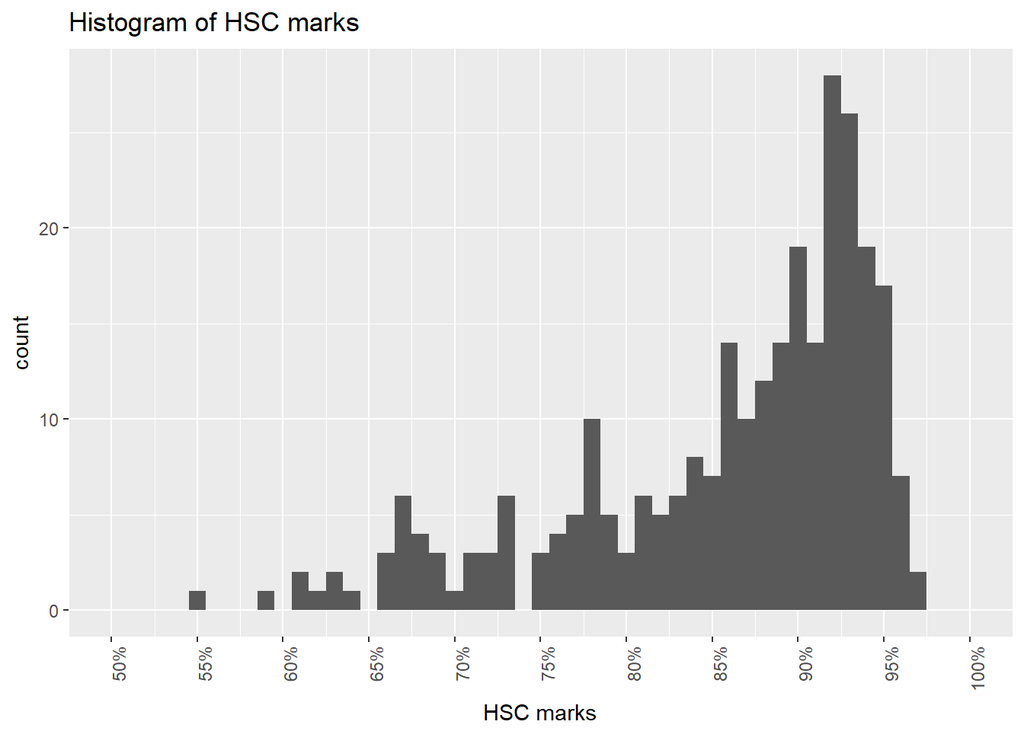

The above histogram represents the distribution of 12th marks.

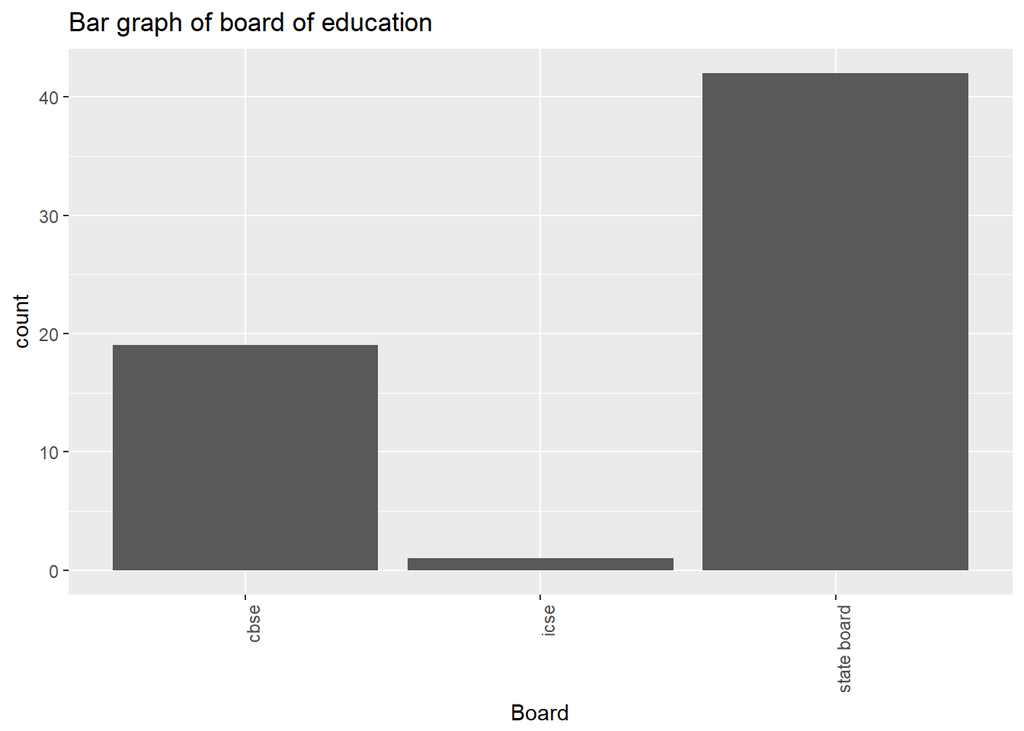

The above bar chart represents the SSLC board of education. Only one student among 281 studied in ICSE. The SSLC board cannot be used to determine the HSC board which the management has not collected.

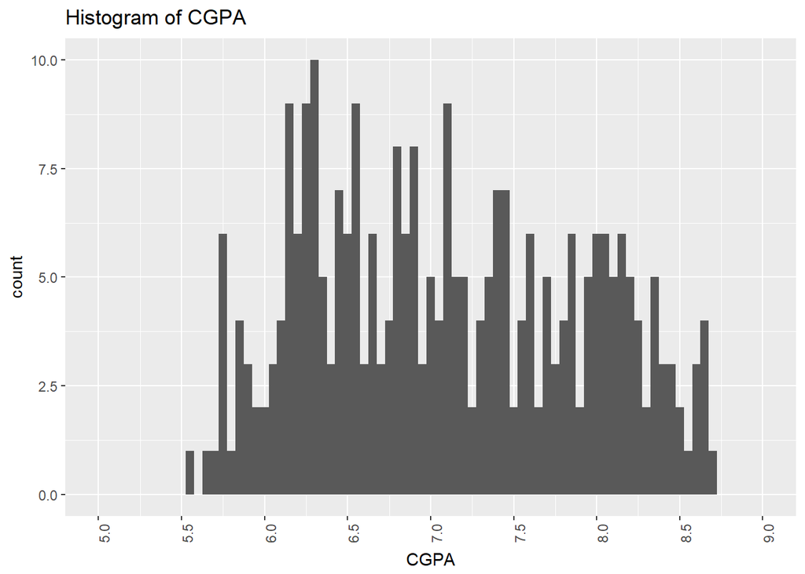

The above histogram represents the distribution of CGPA which mostly falls in between 5.5 and 8.8

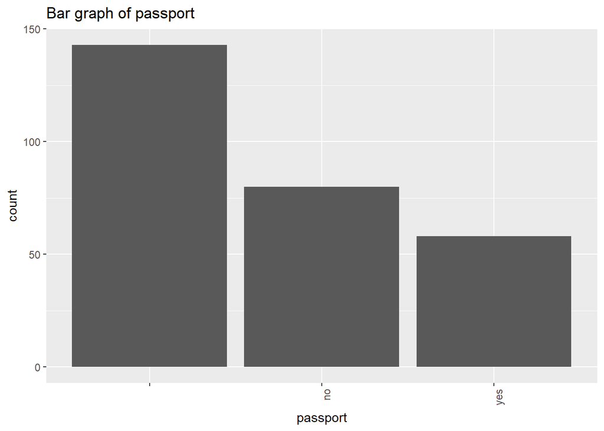

The above bar chart represents the number of students who have passports. The bar which stands out above all is the number of students who have not provided any details. The remaining two represents those who have and those who do not. The students who have their passport MAY have the probability of choosing higher studies instead of getting placed in a company.

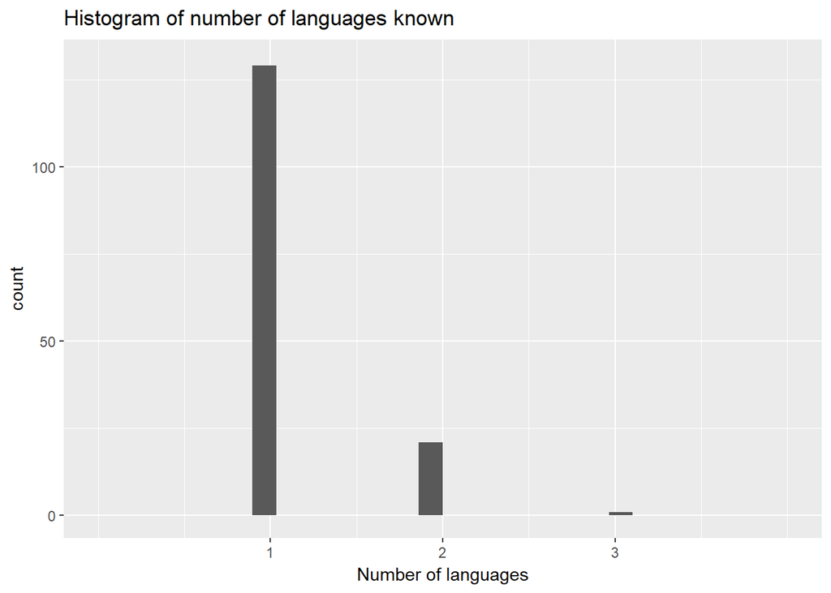

The above histogram represents the number of languages known by the students. From the graph, very few people know more than one language.

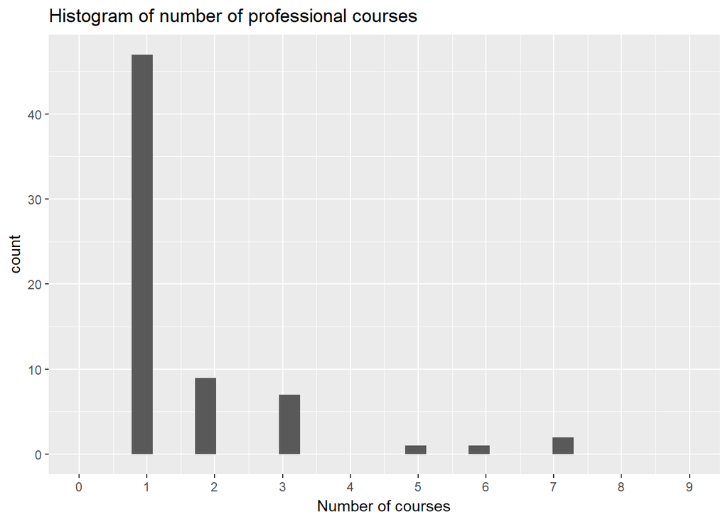

The above one represents the number of professional courses they have learned during the course of study.

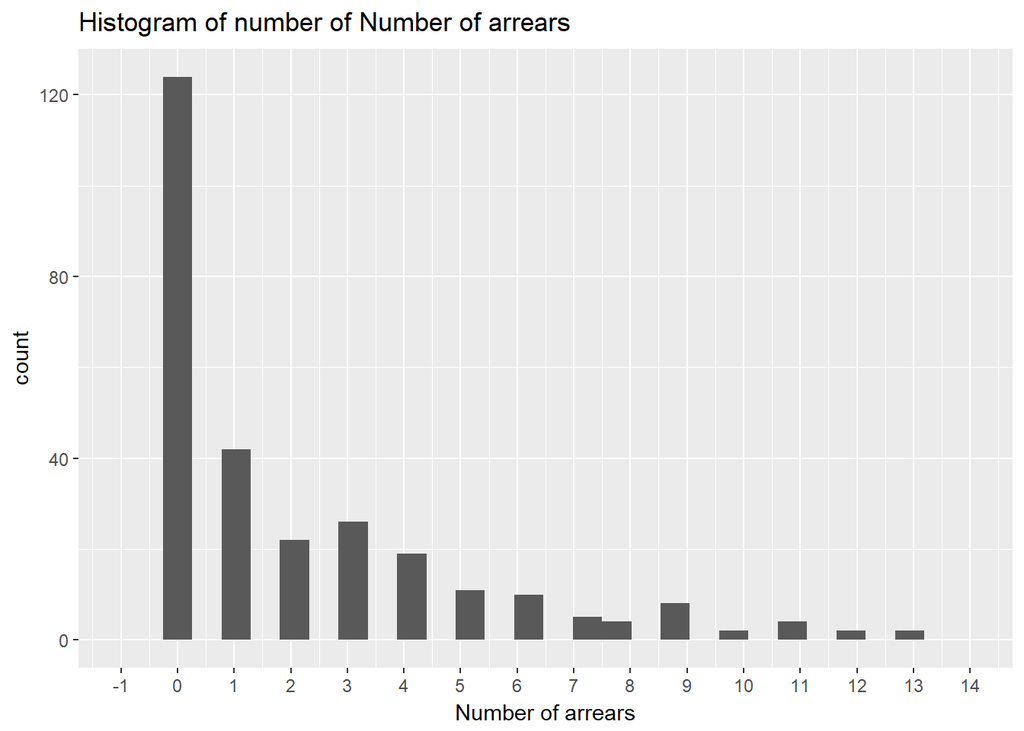

The above histogram represents the number of arrears the students have. The maximum number of arrear is 13.

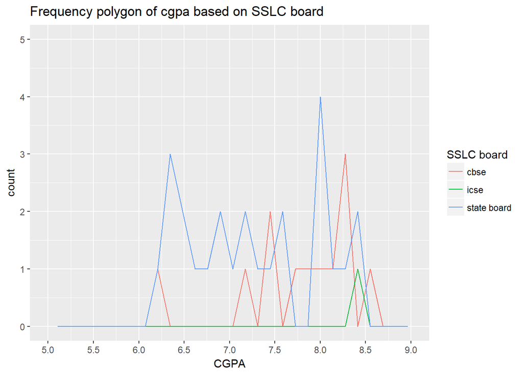

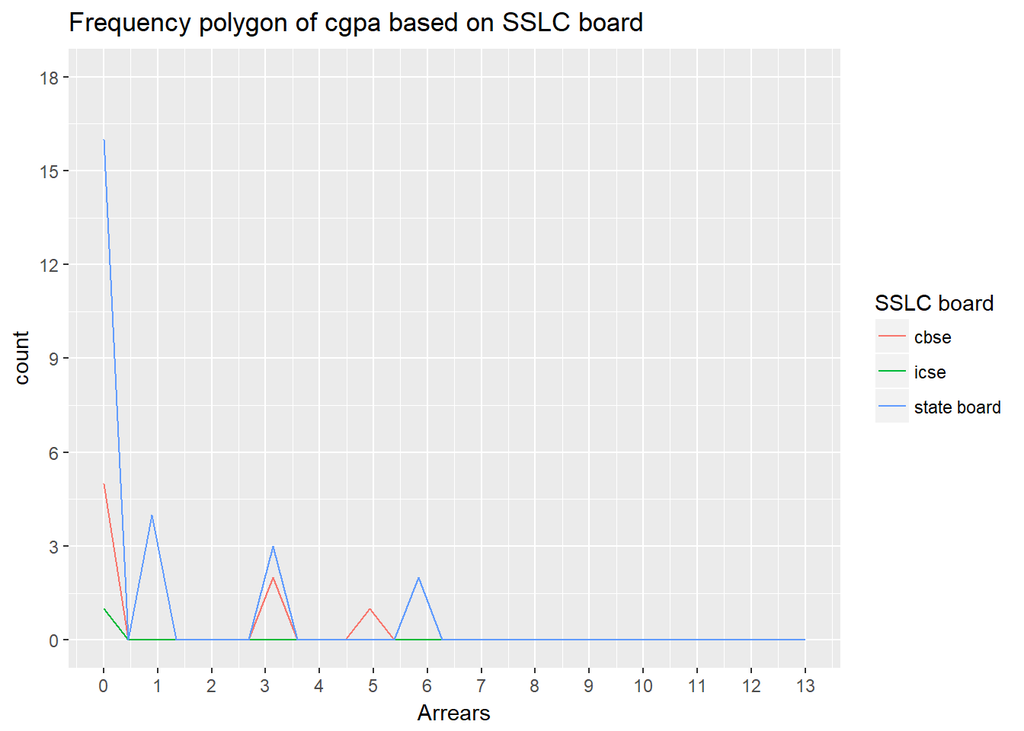

The above frequency polygram represents the number of back logs the students have which is distinguished based on the board of education. The ICSC studen have no arrears. The number of stateboard students who have arrears is comparitively more than the CBSE students.

# Bivariate analysis

```
## # A tibble: 5 x 4
##   Branch arrears     cgpa Number_of_students
##   <fctr>   <int>    <dbl>              <int>
## 1  CSE-A     120 7.042909                 55
## 2  CSE-B     100 7.245000                 58
## 3  CSE-C     115 7.188000                 60
## 4  CSE-D     131 6.989811                 53
## 5  CSE-E     142 7.046909                 55
```

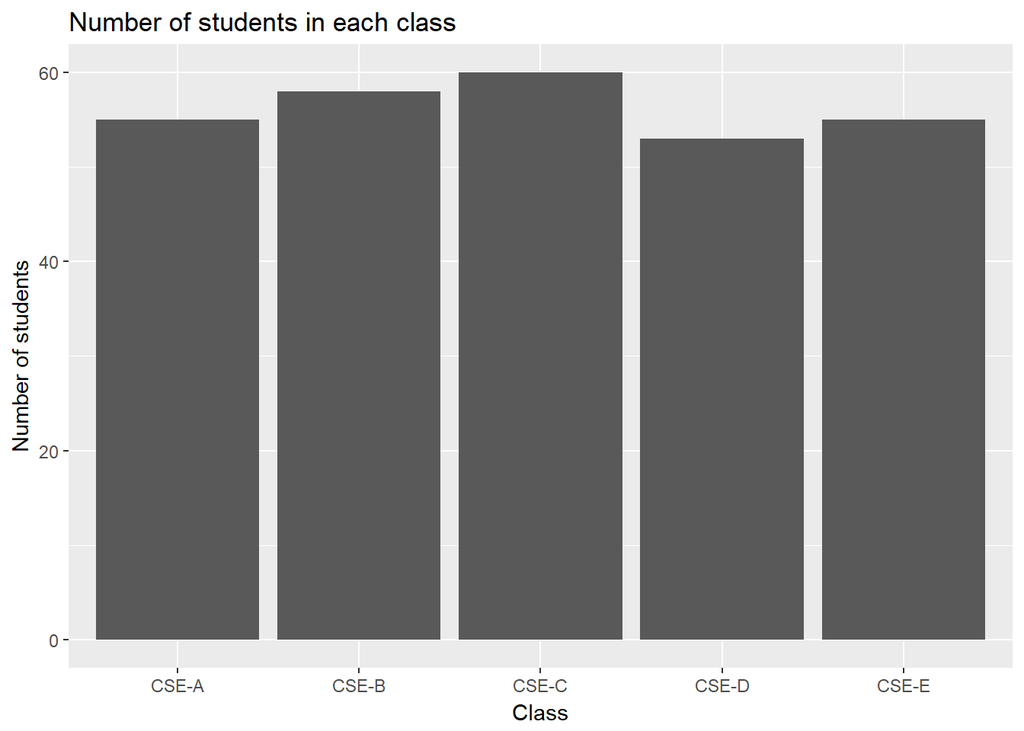

The above bar chart represents the number of students in each class. The order of class from maximum to minimum is C, B, (A, E) and D.

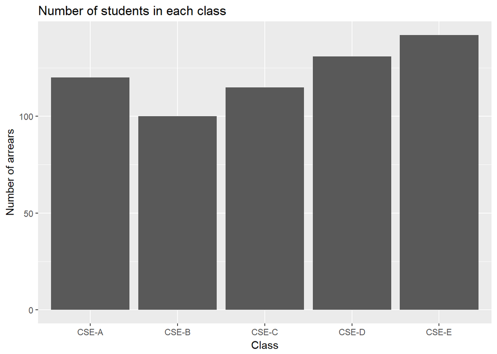

The above bar chart represents the number of arrears based on the class. The section ‘E’ has the maximum number of arrears than the any other class. The remaining in order from high to low are D, A, C and B.

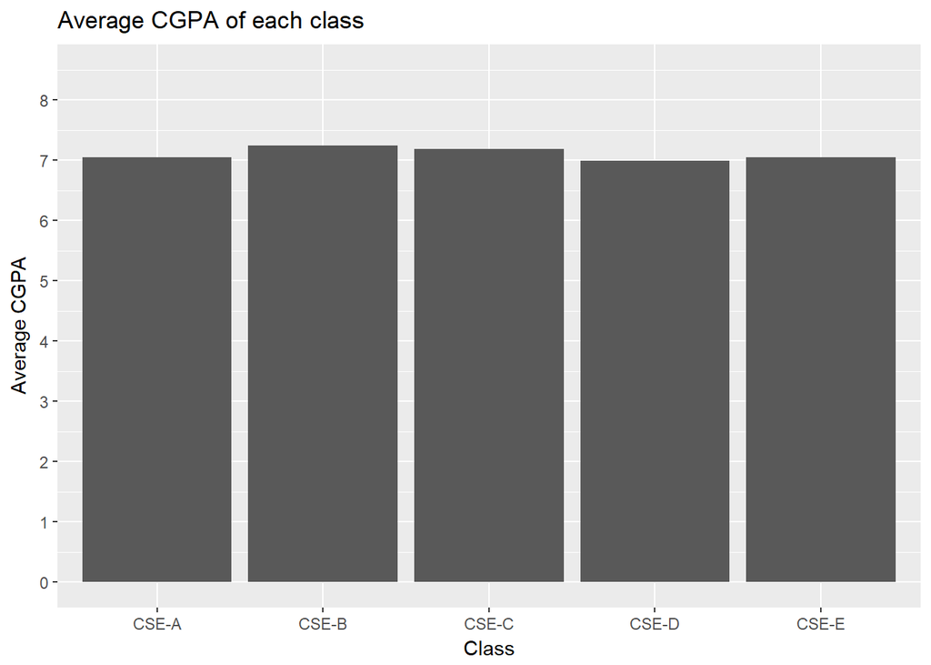

```
## # A tibble: 6 x 3
##         NAME  cgpa courses
##       <fctr> <dbl>   <dbl>
## 1   NITHYA D  8.71       1
## 2  BHARGAV S  8.67       0
## 3 SOWJANYA M  8.67       0
## 4   SOWMYA J  8.66       0
## 5  JOTHIKA K  8.63       7
## 6 BALAJI M P  8.62       1
```

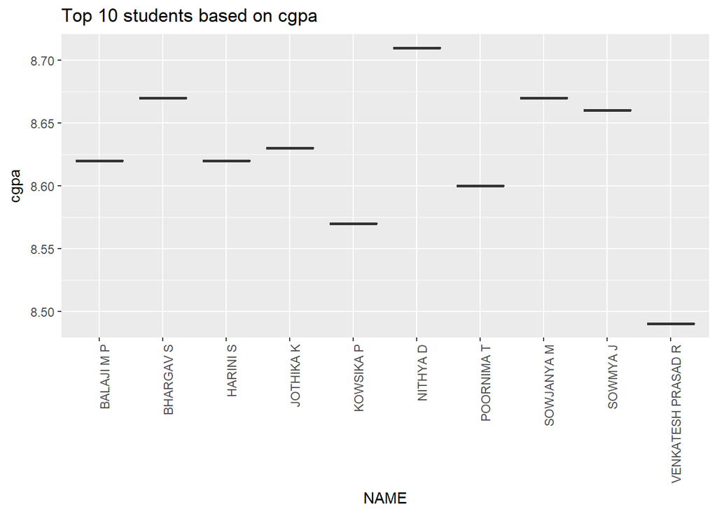

The above graph represents the box plot of top ten students based on their CGPA.

```
## # A tibble: 6 x 2
##             NAME arrears
##           <fctr>   <dbl>
## 1   AJIT SURYA A      12
## 2  ALAGAPPAN R M      10
## 3  ARUNACHALAM B      11
## 4       BALAJI P      11
## 5        GOKUL S      12
## 6 NIROOP KUMAR V      13
```

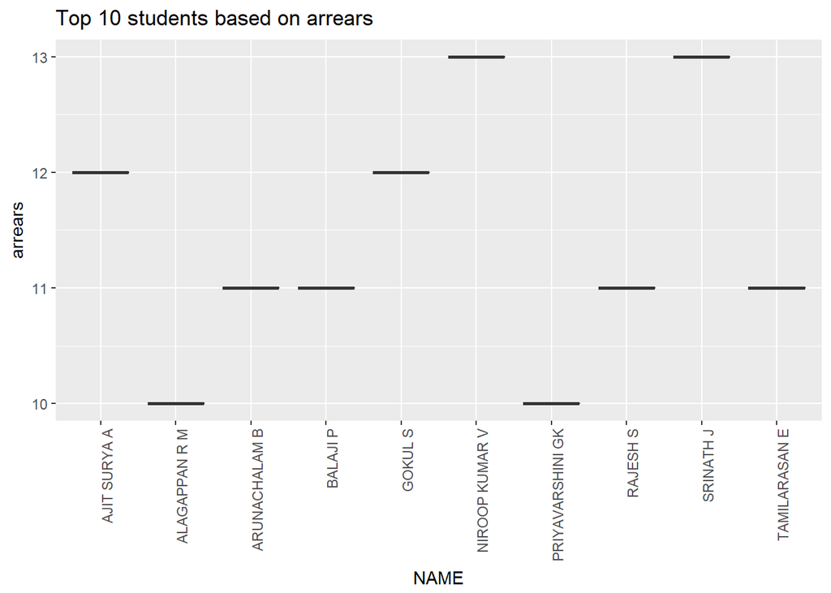

```
## # A tibble: 6 x 2
##                    NAME courses
##                  <fctr>   <dbl>
## 1      ANJANA PREMKUMAR       6
## 2       BUMIJA SRIRAMAN       7
## 3             FATHIMA K       3
## 4 GAYATHIRI RAVISHANKAR       3
## 5             JOTHIKA K       7
## 6              MAHIMA S       3
```

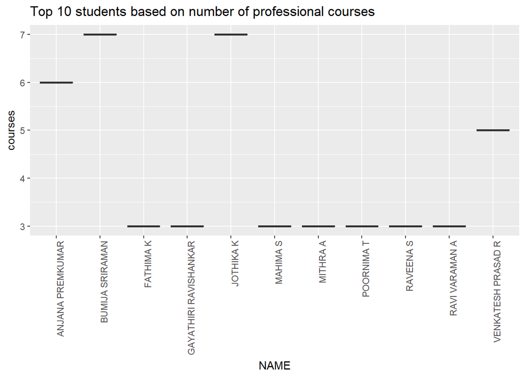

The above one represents the number of professional courses the student’s have done.